# Intensity Normalization

## Overall Pipeline

## Intensity normalization

- Conventional MRI intensites (T1-w, T2-w, PD, FLAIR) are acquired in arbitrary units
- Images are not comparable across scanners, subjects, and visits, even when the same protocol is used.
  - This affects algorithm performance, prediction, inference.
  - Even simple things like thresholding an image
- Intensity normalization brings the intensities to a common scale across people.
- In this tutorial we will normalize intensities within subject using two methods:
  - Whole-brain normalization
  - White Stripe normalization (Shinohara et al. 2014).

## Visualizing whole-brain intensities (each line is a person)

- We will work with the T1-w images from the training data.
- Full brain densities are mixtures of the three tissue class distributions.

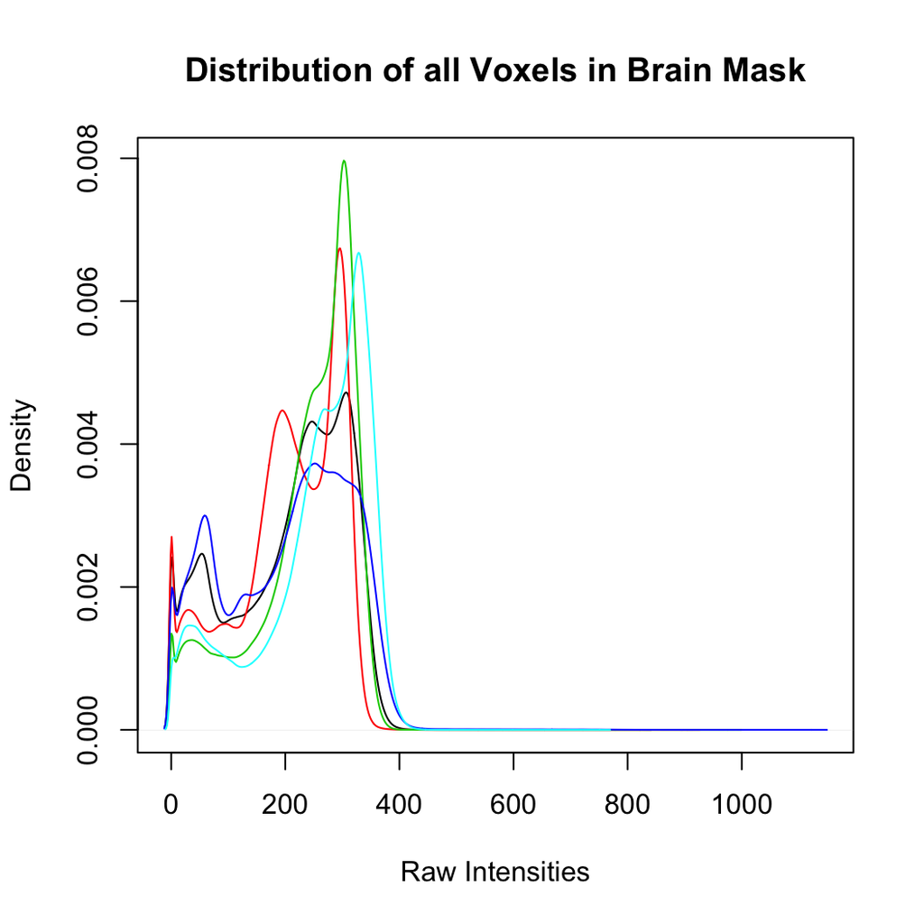

## Visualizing the intensities by tissue class

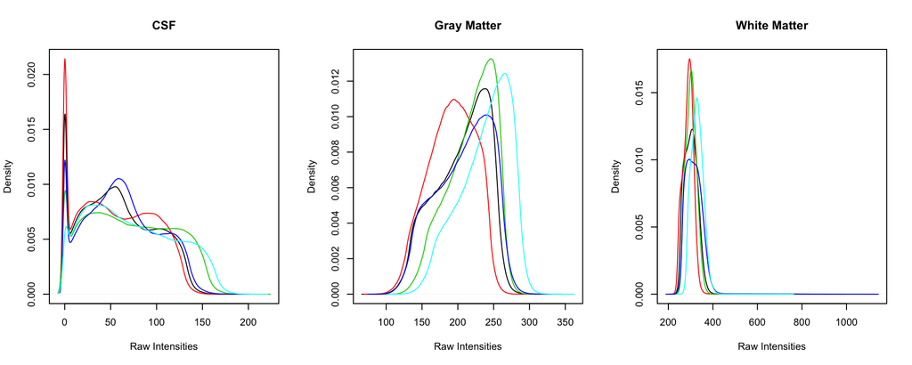

And these are all the same scanner/protocol!

## Whole-brain normalization

- Let’s Z-score each voxel using mean \(\mu_{WB}\) and standard deviation \(\sigma_{WB}\) computed from all voxels in the brain mask.

\[ T1_{WB} = \frac{T1 - \mu_{WB}}{\sigma_{WB}}\]

- `zscore_img` is a function in `neurobase` that does this.
- It takes an image and a binary mask. The default is to use all voxels in the brain mask.

```r
zscore_img(img = img, mask = mask)
```

## Whole-brain normalized intensities

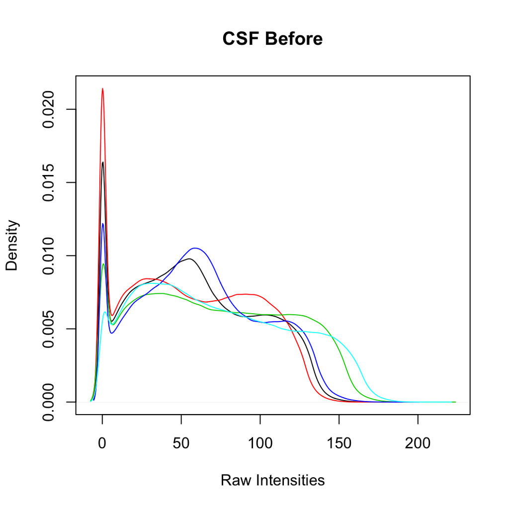

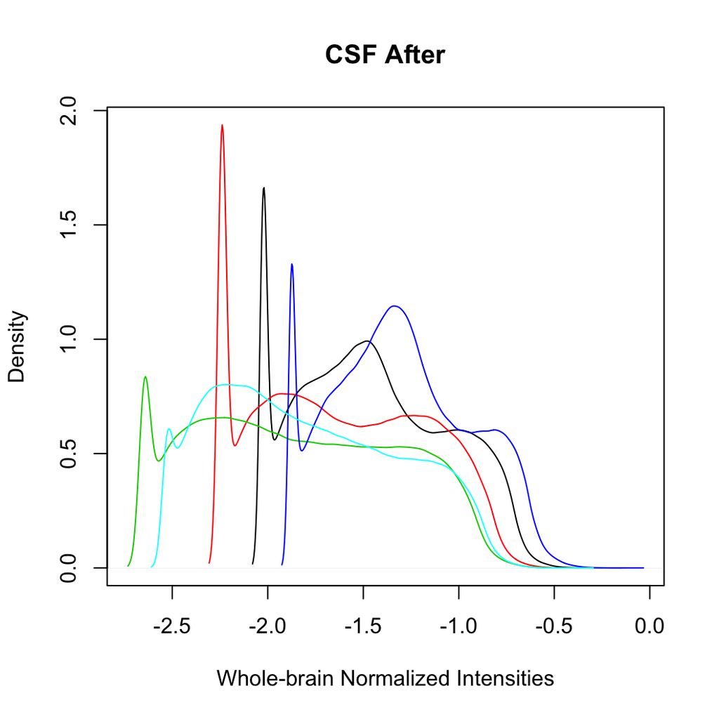

## Whole-brain normalized intensities

- Gray matter distributions are more comparable.

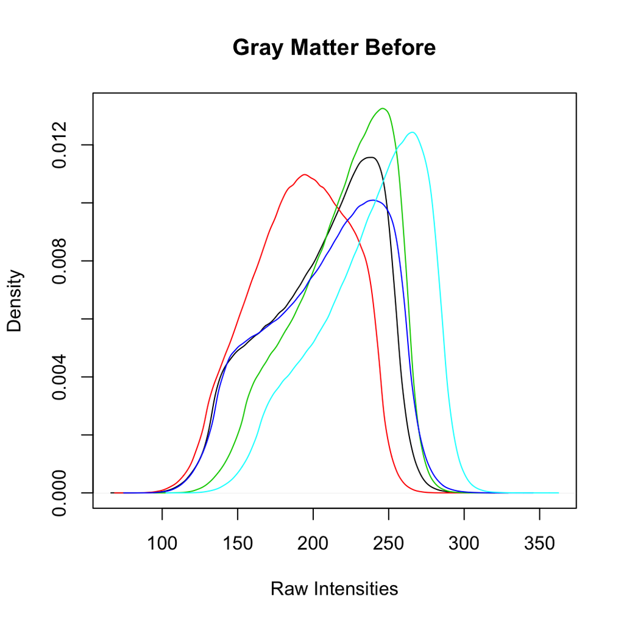

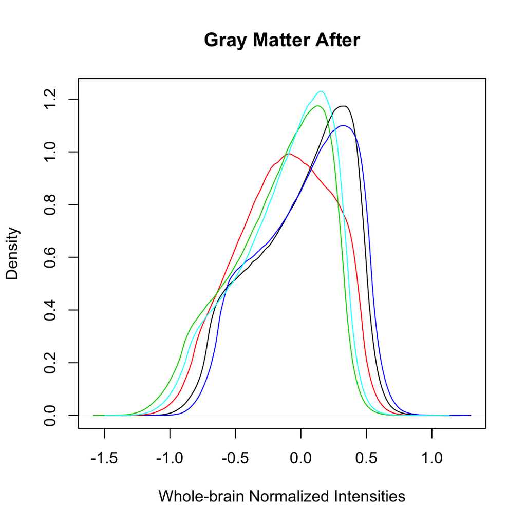

## Whole-brain normalized intensities

- White matter distributions are more comparable.

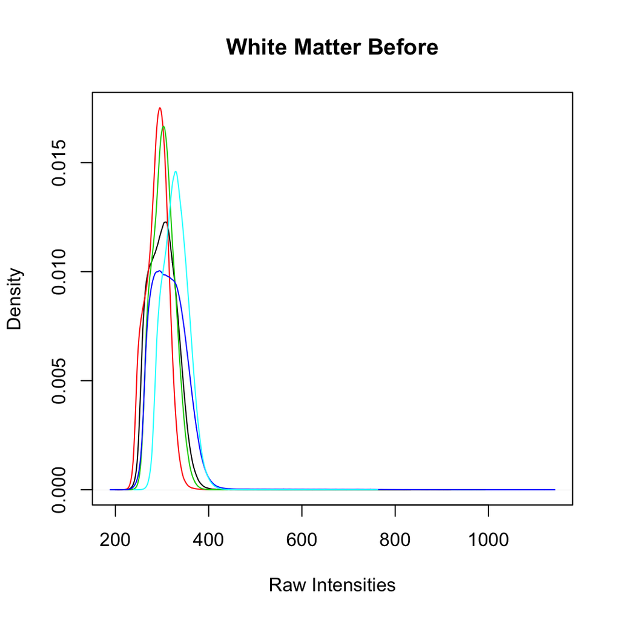

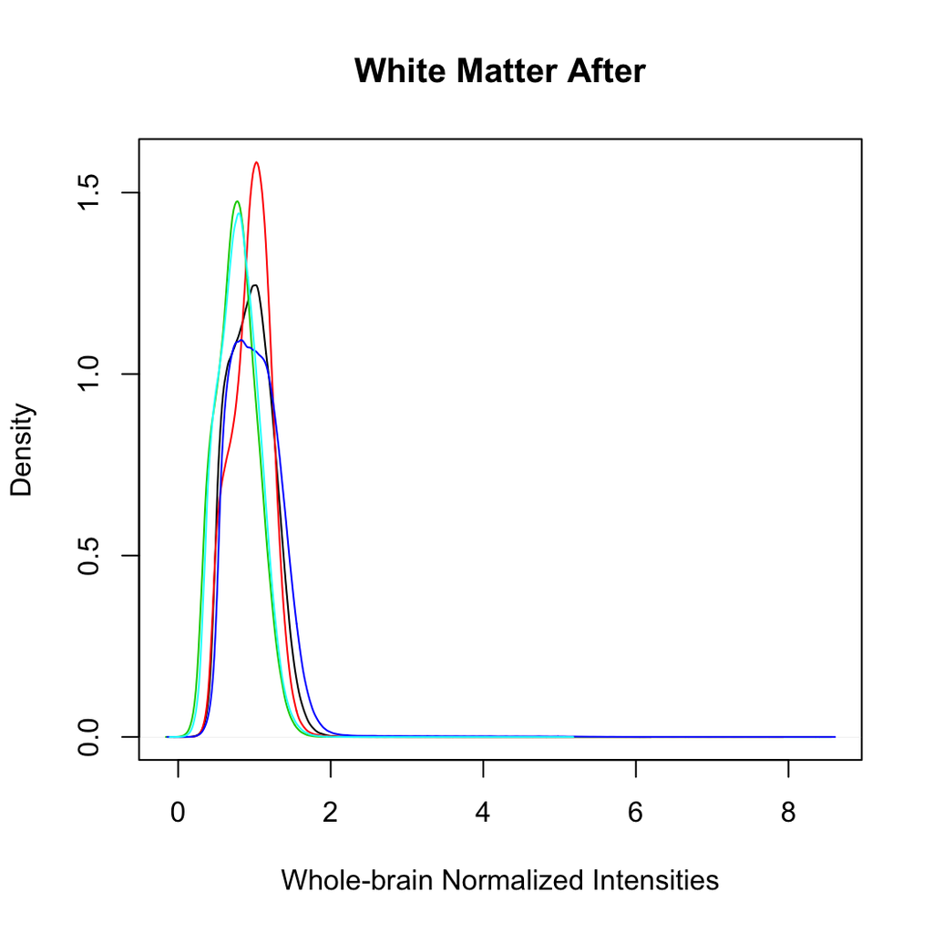

## Other Normalizations: White Stripe

- Whole-brain normalization may be sensitive to outliers.
- Lesions in MS can have very high intensities, which lead to bad estimates of mean/variance
  - Other more robust transformations may be used, such as using the median to center, IQR to scale, etc.
- White Stripe (Shinohara et al. 2014) is based on parameters obtained from a sample of normal appearing white matter (NAWM), which is robust to outliers.
  - The idea is to make normal appearing white matter comparable across subjects and visits.

## White Stripe normalization

Procedure:

1. Find white matter area on histogram

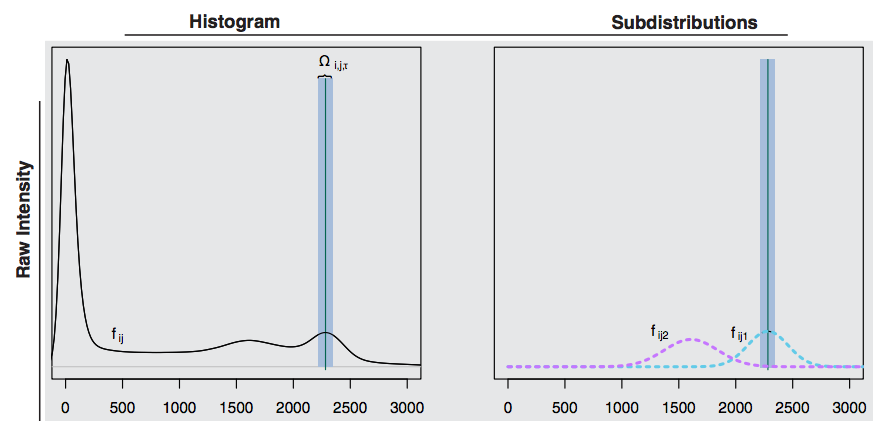

## White Stripe normalization

Procedure:

1. Find white matter area on histogram
2. Estimate mean \(\mu_{WS}\) and variance \(\sigma_{WS}\) of voxel intensities in that area
3. Normalize with those means/variances: \[ T1_{WS} = \frac{T1 - \mu_{WS}}{\sigma_{WS}}\]

## White Stripe normalization

- After normalization, NAWM will have a standard normal distribution and units will be in standard deviations of NAWM.
- Gray matter and CSF distributions may not be comparable after White Stripe.

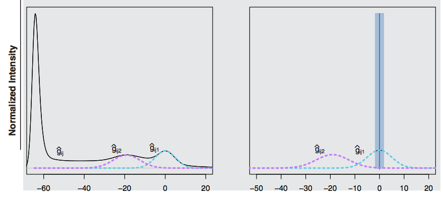

## White Stripe normalization

Procedure:

1. Find white matter area on histogram
2. Estimate mean \(\mu_{WS}\) and variance \(\sigma_{WS}\) of voxel intensities in that area
3. Normalize with those means/variances: \[ T1_{WS} = \frac{T1 - \mu_{WS}}{\sigma_{WS}}\]
- After normalization, NAWM will have a standard normal distribution and units will be in standard deviations of NAWM.
- Gray matter and CSF distributions may not be comparable after White Stripe.

## White Stripe normalization code

```r
library(WhiteStripe)
ind = whitestripe(img = t1, type = "T1", stripped = TRUE)$whitestripe.ind
ws_t1 = whitestripe_norm(t1, indices = ind)
```

- The `whitestripe` function takes an image, image type (in our case T1), and a logical indicating whether the image has been skull stripped.
- The indicies of voxels in the NAWM used for estimating the normalization parameters are located in the list element `$whitestripe.ind`.
- The function `whitestripe_norm` takes an image and the indicies from a call to `whitestripe` and returns the White Stripe normalized image as a nifti.

## WhiteStripe normalized intensities

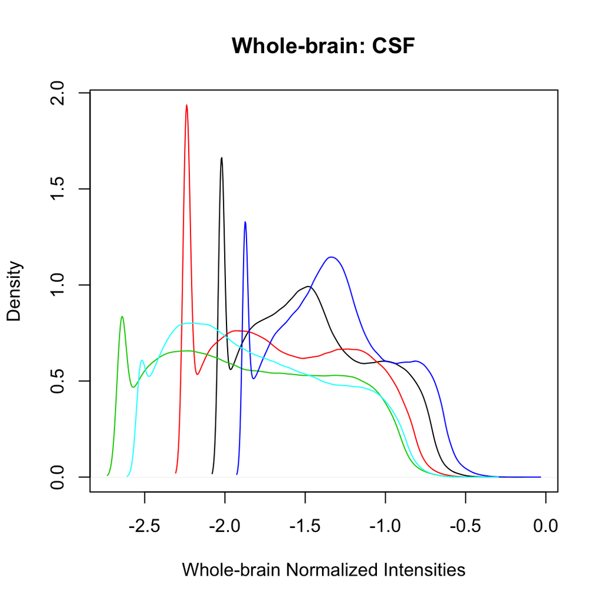

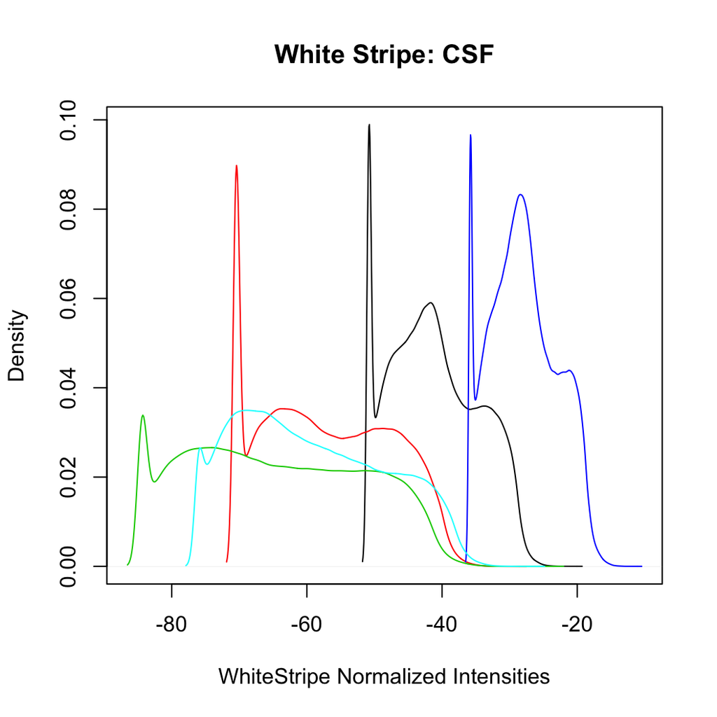

## WhiteStripe normalized intensities

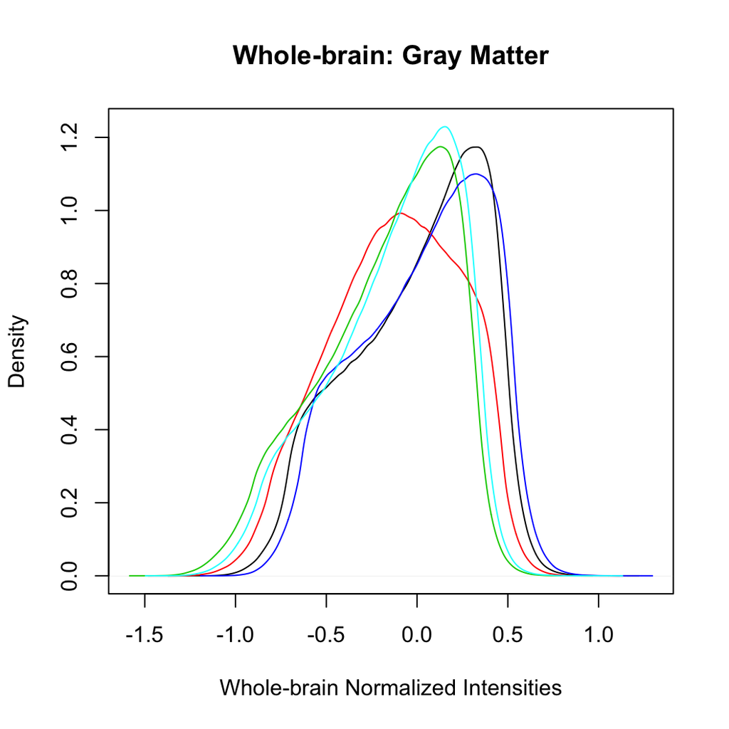

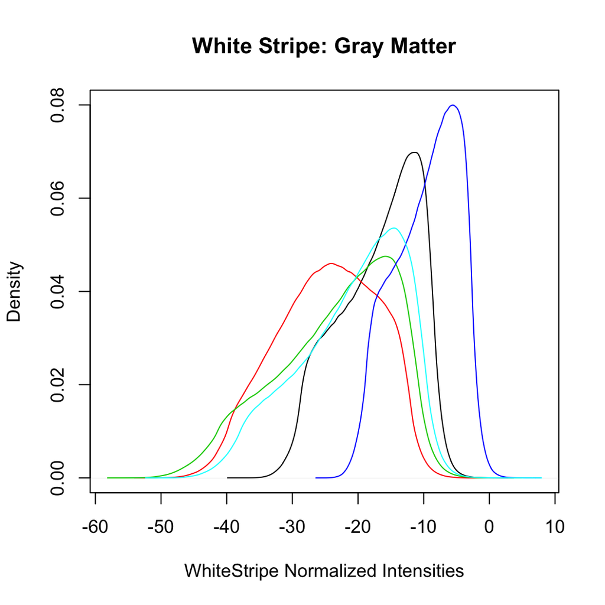

## WhiteStripe normalized intensities

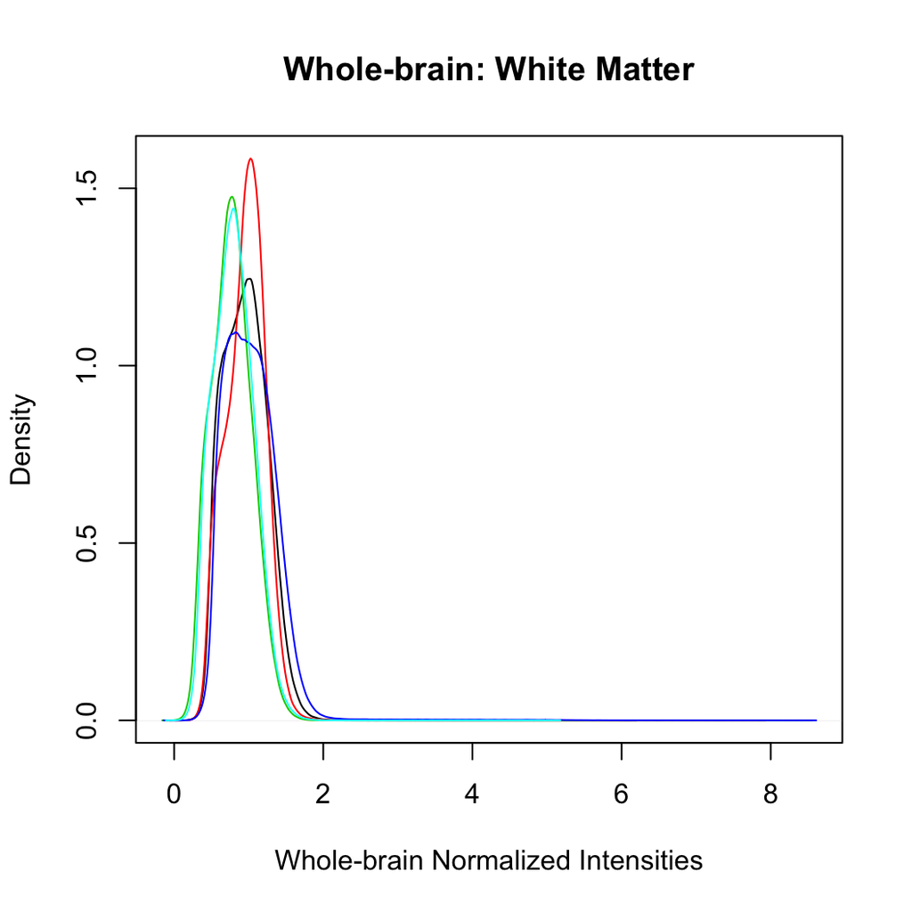

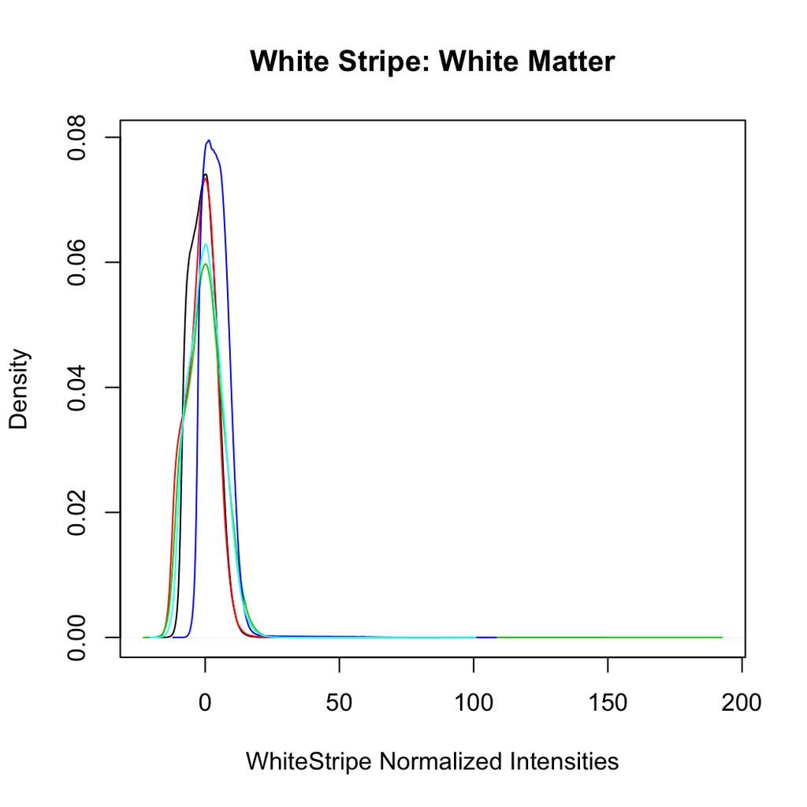

## Conclusions

- Intensity normalization is an important step in any image analysis with more than one subject or time point to ensure comparability across images.
- White Stripe normalization may work better and have better interpretation than whole-brain normalization for subsequent lesion segmentation algorithms and analysis.
- Other intensity normalization methods that make intensites comparable across subjects for all tissues exist.
  - RAVEL, which is an extension of WhiteStripe is one example (Fortin et al. 2016).
  - Located at https://github.com/Jfortin1/RAVEL
    - This was shown to have better comparability than histogram matching

## Website

http://johnmuschelli.com/imaging_in_r

## References

Fortin, Jean-Philippe, Elizabeth M Sweeney, John Muschelli, Ciprian M Crainiceanu, Russell T Shinohara, Alzheimer’s Disease Neuroimaging Initiative, and others. 2016. “Removing Inter-Subject Technical Variability in Magnetic Resonance Imaging Studies.” *NeuroImage* 132. Elsevier:198–212.

Shinohara, Russell T, Elizabeth M Sweeney, Jeff Goldsmith, Navid Shiee, Farrah J Mateen, Peter A Calabresi, Samson Jarso, et al. 2014. “Statistical Normalization Techniques for Magnetic Resonance Imaging.” *NeuroImage: Clinical* 6. Elsevier:9–19.